# beakerbanter_hawaii_tns

Taiki Sakai

2022-11-21

## Data Processing for Beaked Whales: Hawaii

Start by loading the required packages

```r
library(PAMpal)
library(banter)
library(rfPermute)
```

### PAMpal Processing

Set up our PPS for the Hawaii dataset

```r
pps <- PAMpalSettings(db='hawaii/Database_JMc/',
                      binaries = 'hawaii/Binaries_new/',
                      sr_hz='auto',
                      winLen_sec=.0025,
                      filterfrom_khz=10,
                      filterto_khz=NULL)
```

Process data and save to file so we don’t have to process again, comment out processing and saving lines and uncomment reading line if you’ve already done this. We’ll also check to see if there were any warning messages during processing.

```r
data <- processPgDetections(pps, mode='db', id='Hawaii_BBW')
saveRDS(data, 'hawaii/hiceas_study.rds')
# Double check warning messages
print(getWarnings(data)$message)
```

Assign species IDs according to original Pamguard labels, then relabel them for consistency across projects

```r
data <- setSpecies(data, 'pamguard')
reSpecies <- readRDS('hawaii/species.rds')
print(reSpecies)
```

```
##     X     old      new
## 1  11     ?BW   possBW
## 2  38     ?GG   possGG
## 3  13   ?NBHF possNBHF
## 4  17     ?PM   possPM
## 5  22     ?Pm   possPM
## 6   9     BW?   possBW
## 7   7 BW26.47       BW
## 8   8 BW26-47       BW
## 9   1 BW34.50    BW39V
## 10  2 BW34-50    BW39V
## 11  6    BW38       BW
## 12  3    BW46       MS
## 13  4 BW50.75       MS
## 14  5 BW50-75       MS
## 15 18  BWunid       BW
## 16 42      Oo       OO
## 17 36      Pm       PM
## 18 44    Ship     SHIP
## 19 10      Zc       ZC
```

```r
data <- setSpecies(data, 'reassign', value=reSpecies)
```

```
## 10 species (UO, MD, IP, UNK, BWC, NBHF, ... (4 more not shown)) were not in reassignment dataframe, they have not been changed.
```

Filtering out unwanted data before sending off to BANTER. First we only want a subset of species (and we also rename these for clarity later). Second the Hawaii data has issues with the second hydrophone, so we filter down to only the first channel

```r
goodSpecies<- c("ZC", "MD", "BW", "BWC", "IP", "BW", "possBW")
data <- filter(data, species %in% goodSpecies)
data <- setSpecies(data, method='reassign',
                   value=data.frame(old=c('ZC', 'MD', 'BWC', 'IP'), new=c("Cuviers", "Blainsvilles", "CrossSeamount", "Indopacetus")))
```

```
## 2 species (possBW, BW) were not in reassignment dataframe, they have not been changed.
```

```r
ch1only <- filter(data, Channel == '1')
```

We also want to use ICI in one of our models, so we’ll calculate that.

```r
ch1only <- calculateICI(ch1only, time='peakTime')
```

```r
bntDataIci <- export_banter(ch1only, dropSpecies = c("BW", "possBW"), training=TRUE)
bntData <- export_banter(ch1only, dropSpecies = c('BW', 'possBW'),
                         dropVars = c('All_ici'), training=TRUE)
saveRDS(bntData, file='hawaii/hiceas_bntData.rds')
saveRDS(bntData, file='hawaii/hiceas_bntDataIci.rds')
```

### BANTER Training

Train our non-ICI model first, check stability of detector models before running full banter.

```r
bntMdl <- initBanterModel(bntData$events)
# was 30e3 / 1 in SRs initial, too much memory. 5e3/1 is 210mb and takes ~10min
bntMdl <- addBanterDetector(bntMdl, bntData$detectors, ntree=5e3, sampsize=1, importance = TRUE)
```

Check for stability to see if we need more trees

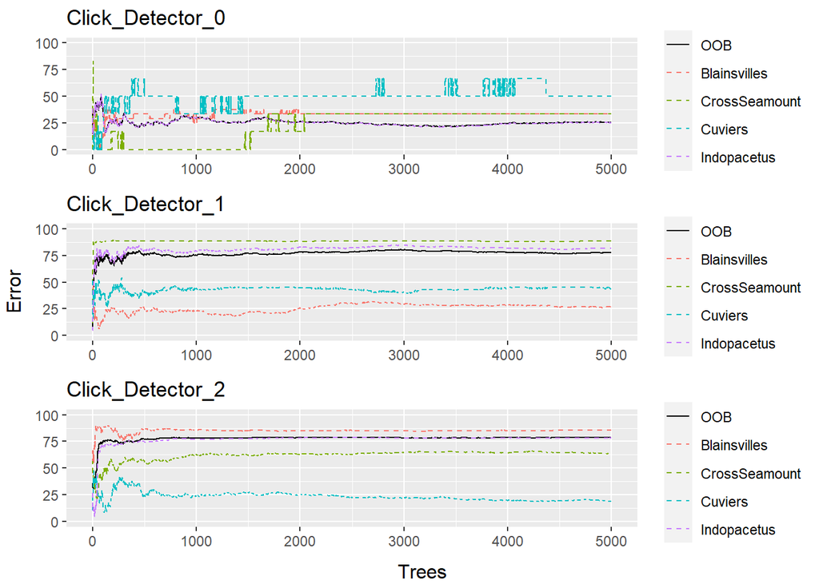

```r
plotDetectorTrace(bntMdl, detector = paste0('Click_Detector_', 0:2))
```

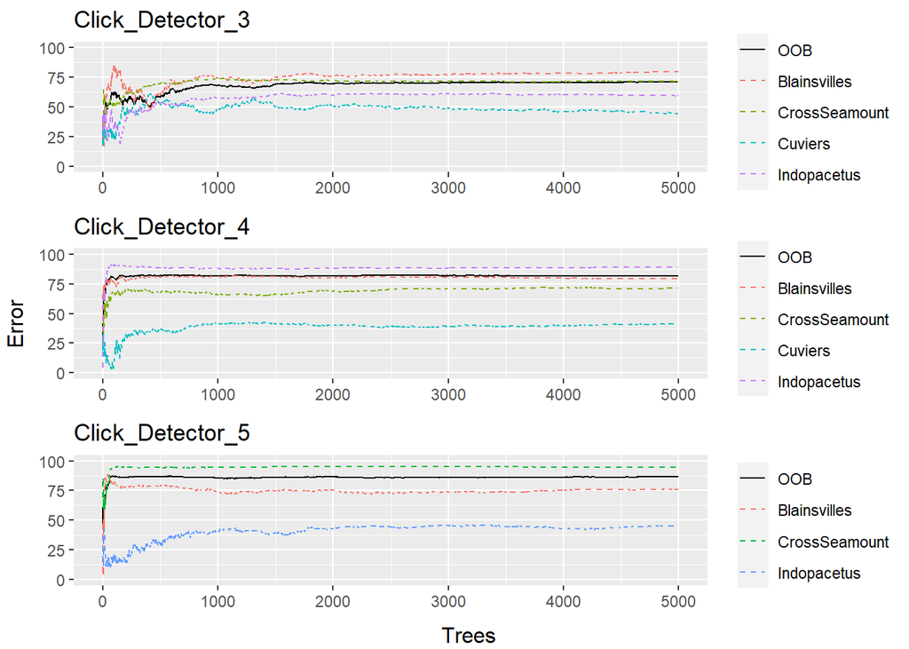

```r
plotDetectorTrace(bntMdl, detector = paste0('Click_Detector_', 3:5))
```

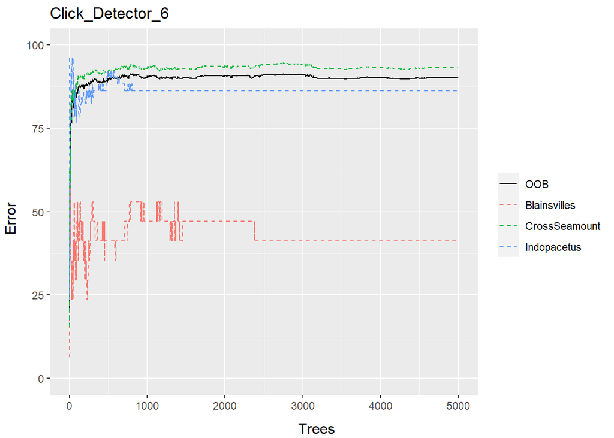

```r
plotDetectorTrace(bntMdl, detector = paste0('Click_Detector_', 6))
```

```r
summary(bntMdl)
```

```
## Model run times:
##                  start                 stop                  run.time
## Click_Detector_0 "2022-11-23 17:42:17" "2022-11-23 17:42:18" "1 secs"
## Click_Detector_1 "2022-11-23 17:41:42" "2022-11-23 17:42:17" "34.6 secs"
## Click_Detector_2 "2022-11-23 17:37:39" "2022-11-23 17:39:25" "1.76 mins"
## Click_Detector_3 "2022-11-23 17:39:25" "2022-11-23 17:41:09" "1.74 mins"
## Click_Detector_4 "2022-11-23 17:41:09" "2022-11-23 17:41:42" "33.08 secs"
## Click_Detector_5 "2022-11-23 17:42:18" "2022-11-23 17:42:20" "1.66 secs"
## Click_Detector_6 "2022-11-23 17:42:17" "2022-11-23 17:42:17" "0.21 secs"
## event            "2022-11-23 17:53:06" "2022-11-23 17:53:18" "11.66 secs"
##
## Number of events and model classification rate:
##         species num.events Click_Detector_0 Click_Detector_1 Click_Detector_2
## 1  Blainsvilles        521            33.33            27.09            85.51
## 2 CrossSeamount         76            33.33            88.34            63.23
## 3       Cuviers        201            50.00            43.66            18.56
## 4   Indopacetus        122            24.92            81.82            78.43
## 5       Overall        920            25.18            77.75            78.59
##   Click_Detector_3 Click_Detector_4 Click_Detector_5 Click_Detector_6 event
## 1            79.69            79.28            76.10            41.18 87.52
## 2            71.36            71.60            94.82            93.26 94.74
## 3            44.77            41.32               NA               NA 84.08
## 4            59.58            89.19            44.85            86.27 97.54
## 5            71.04            81.81            86.69            90.22 88.70
```

```
##
## << Summary for "event" model >>
```

```
##
## Number of trees: 10000
##
## Sample sizes:
##  Blainsvilles CrossSeamount       Cuviers   Indopacetus
##             4             4             4             4
##
## Distribution of percent correctly classified overall in last 5000 (50%) trees:
##    Min. 1st Qu.  Median    Mean 3rd Qu.    Max.
##   88.59   88.70   88.80   88.78   88.80   88.91
##
## Sample inbag proportion distribution:
##          Min. 1st Qu. Median Mean 3rd Qu. Max.
## expected  0.8     1.7    2.6  2.8     3.8  5.3
## observed  0.5     0.7    0.9  1.7     2.1  5.9
##
## Confusion matrix:
##               Blainsvilles CrossSeamount Cuviers Indopacetus pct.correct
## Blainsvilles           456            15      46           4    87.52399
## CrossSeamount            3            72       1           0    94.73684
## Cuviers                 19             0     169          13    84.07960
## Indopacetus              0             0       3         119    97.54098
## Overall                 NA            NA      NA          NA    88.69565
##               LCI_0.95 UCI_0.95
## Blainsvilles  84.37613 90.23783
## CrossSeamount 87.06908 98.54754
## Cuviers       78.27488 88.84841
## Indopacetus   92.98183 99.48999
## Overall       86.47015 90.66963
```

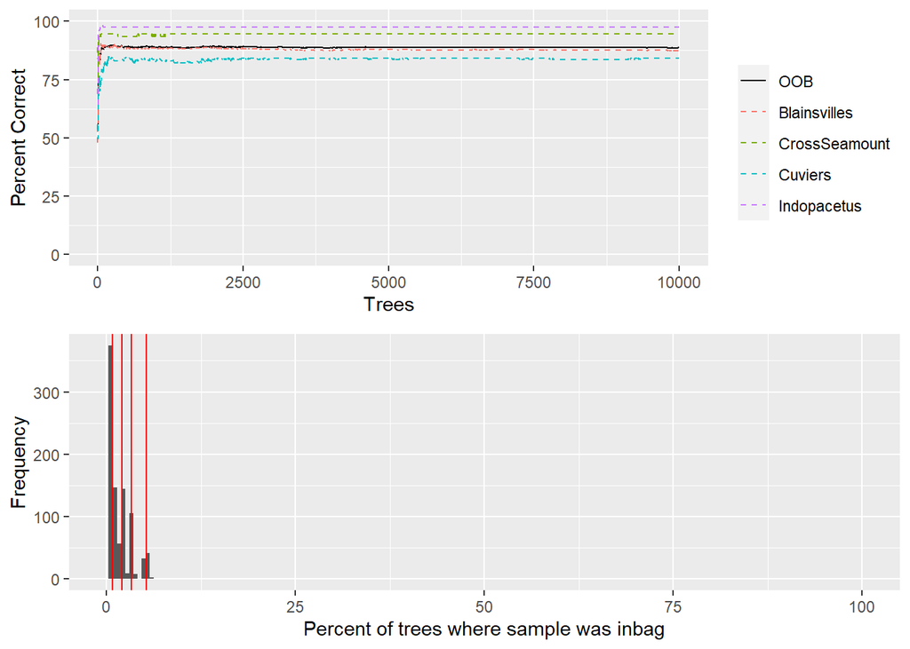

Looks fine, run full event banter model

```r
bntMdl <- runBanterModel(bntMdl, ntree=10e3, sampsize=4)
summary(bntMdl)
```

Looks fine so lets save it. We’re storing the tree/sampsize info in the filename

```r
saveRDS(bntMdl, 'hawaii/hiceas_bntMdl_5e31_10e34.rds')
```

Repeat for ICI model

```r
bntMdlIci <- initBanterModel(bntDataIci$events)
# was 30e3 / 1 in SRs initial, too much memory. 5e3/1 is 210mb and takes ~10min
bntMdlIci <- addBanterDetector(bntMdlIci, bntDataIci$detectors, ntree=5e3, sampsize=1, importance = TRUE)
```

Check for stability to see if we need more trees

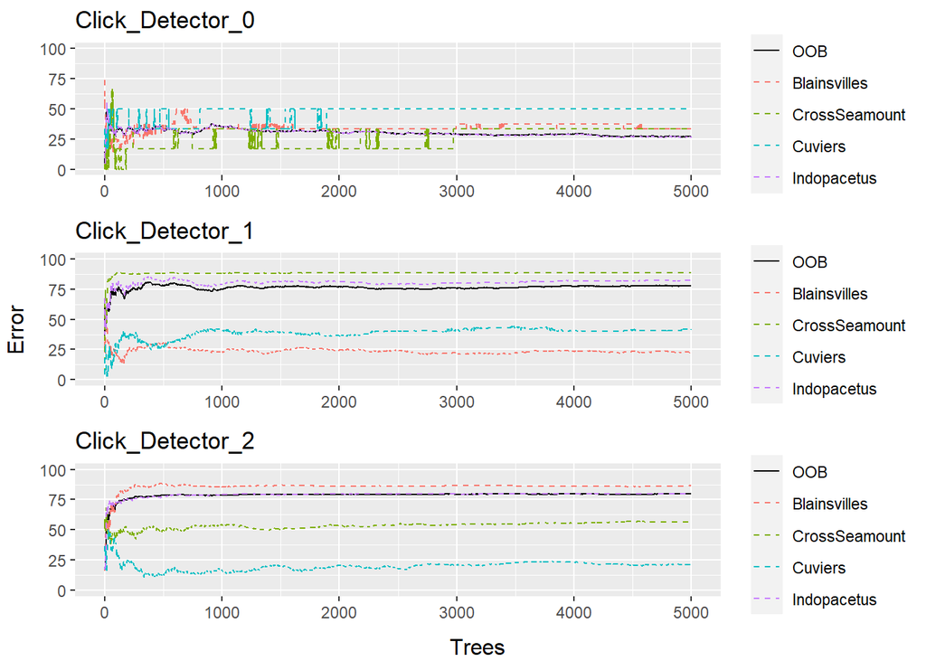

```r
plotDetectorTrace(bntMdlIci, detector = paste0('Click_Detector_', 0:2))
```

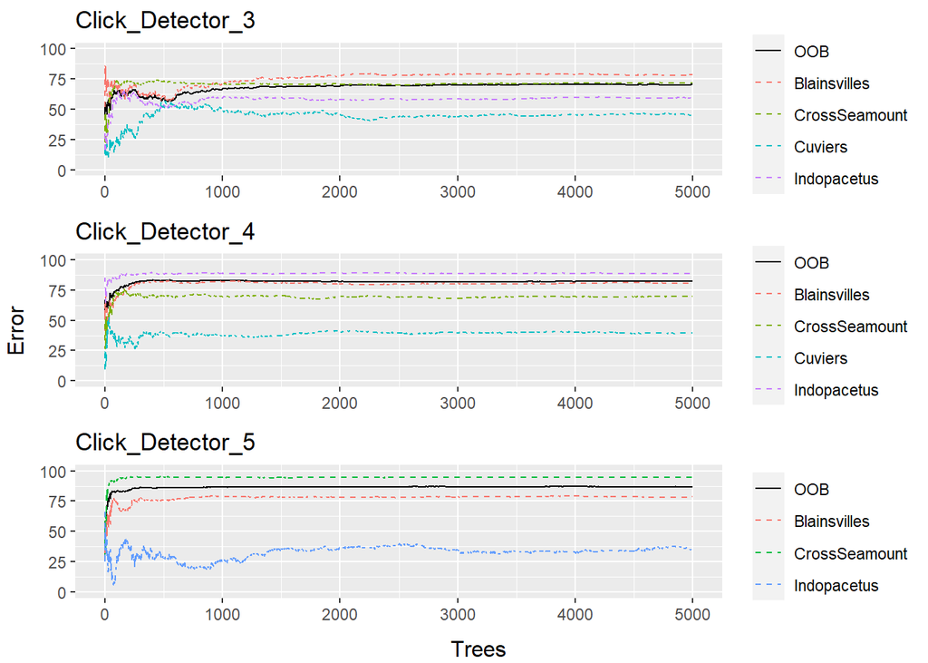

```r
plotDetectorTrace(bntMdlIci, detector = paste0('Click_Detector_', 3:5))
```

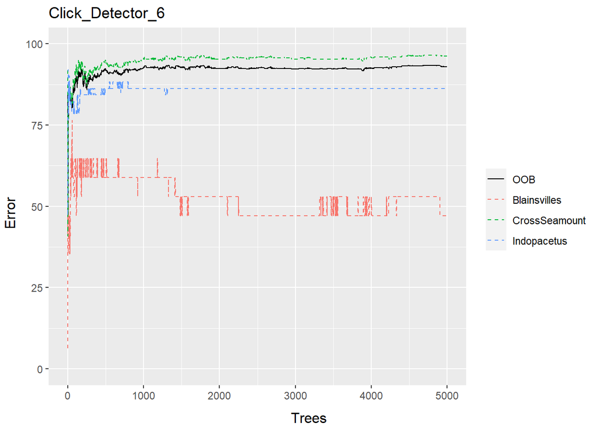

```r
plotDetectorTrace(bntMdlIci, detector = paste0('Click_Detector_', 6))
```

```r
summary(bntMdlIci)
```

```
## Model run times:
##                  start                 stop                  run.time
## Click_Detector_0 "2022-11-23 18:02:44" "2022-11-23 18:02:45" "1 secs"
## Click_Detector_1 "2022-11-23 18:02:09" "2022-11-23 18:02:44" "35.06 secs"
## Click_Detector_2 "2022-11-23 17:58:09" "2022-11-23 17:59:40" "1.5 mins"
## Click_Detector_3 "2022-11-23 17:59:40" "2022-11-23 18:01:35" "1.92 mins"
## Click_Detector_4 "2022-11-23 18:01:35" "2022-11-23 18:02:09" "34.03 secs"
## Click_Detector_5 "2022-11-23 18:02:45" "2022-11-23 18:02:46" "1.67 secs"
## Click_Detector_6 "2022-11-23 18:02:44" "2022-11-23 18:02:44" "0.2 secs"
## event            "2022-11-23 18:06:34" "2022-11-23 18:06:46" "11.4 secs"
##
## Number of events and model classification rate:
##         species num.events Click_Detector_0 Click_Detector_1 Click_Detector_2
## 1  Blainsvilles        521            33.33            22.60            86.47
## 2 CrossSeamount         76            33.33            88.42            56.27
## 3       Cuviers        201            50.00            41.55            21.28
## 4   Indopacetus        122            27.08            82.27            79.86
## 5       Overall        920            27.28            77.78            79.66
##   Click_Detector_3 Click_Detector_4 Click_Detector_5 Click_Detector_6 event
## 1            78.39            80.70            78.52            47.06 91.55
## 2            71.62            69.65            94.59            96.19 93.42
## 3            44.85            39.31               NA               NA 83.58
## 4            59.54            88.83            34.55            86.27 97.54
## 5            70.33            82.21            86.91            92.91 90.76
```

```
##
## << Summary for "event" model >>
```

```
##
## Number of trees: 10000
##
## Sample sizes:
##  Blainsvilles CrossSeamount       Cuviers   Indopacetus
##             4             4             4             4
##
## Distribution of percent correctly classified overall in last 5000 (50%) trees:
##    Min. 1st Qu.  Median    Mean 3rd Qu.    Max.
##   90.22   90.54   90.65   90.66   90.76   90.98
##
## Sample inbag proportion distribution:
##          Min. 1st Qu. Median Mean 3rd Qu. Max.
## expected  0.8     1.7    2.6  2.8     3.8  5.3
## observed  0.5     0.7    0.9  1.7     2.1  5.9
##
## Confusion matrix:
##               Blainsvilles CrossSeamount Cuviers Indopacetus pct.correct
## Blainsvilles           477            12      28           4    91.55470
## CrossSeamount            2            71       3           0    93.42105
## Cuviers                 17             1     168          15    83.58209
## Indopacetus              0             0       3         119    97.54098
## Overall                 NA            NA      NA          NA    90.76087
##               LCI_0.95 UCI_0.95
## Blainsvilles  88.82835 93.79671
## CrossSeamount 85.31096 97.82949
## Cuviers       77.72304 88.42107
## Indopacetus   92.98183 99.48999
## Overall       88.70247 92.55351
```

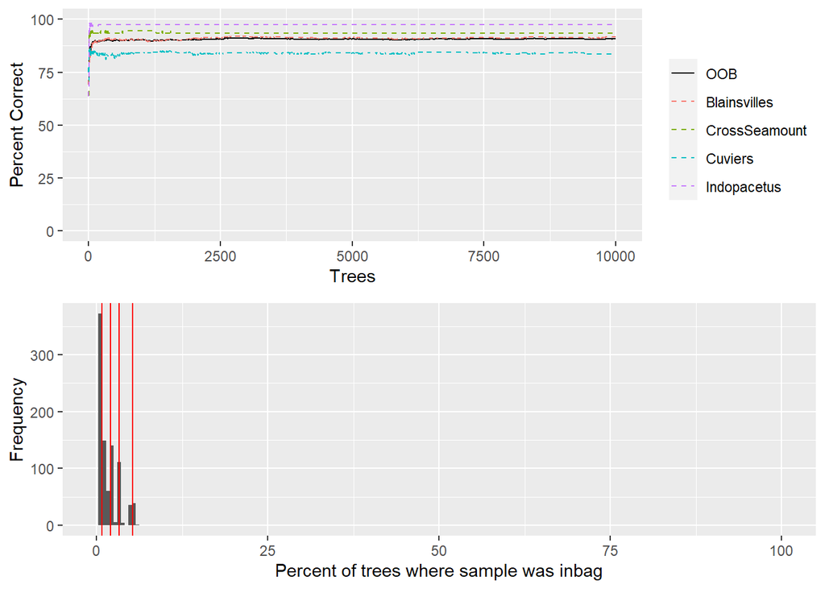

```r
bntMdlIci <- runBanterModel(bntMdlIci, ntree=10e3, sampsize=4)
summary(bntMdlIci)
```

Looks fine so lets save it. We’re storing the tree/sampsize info in the filename

```r
saveRDS(bntMdlIci, 'hawaii/hiceas_bntMdlIci_5e31_10e34.rds')
```

### BANTER Analytics

First extract just the Random Forest part of our BANTER model for analysis. We’ll use the model with ICI included since that performed better.

```r
bntMdlRf <- getBanterModel(bntMdlIci)
```

Confusion Matrix

```r
confusionMatrix(bntMdlRf)
```

```
##               Blainsvilles CrossSeamount Cuviers Indopacetus pct.correct
## Blainsvilles           477            12      28           4    91.55470
## CrossSeamount            2            71       3           0    93.42105
## Cuviers                 17             1     168          15    83.58209
## Indopacetus              0             0       3         119    97.54098
## Overall                 NA            NA      NA          NA    90.76087
##               LCI_0.95 UCI_0.95
## Blainsvilles  88.82835 93.79671
## CrossSeamount 85.31096 97.82949
## Cuviers       77.72304 88.42107
## Indopacetus   92.98183 99.48999
## Overall       88.70247 92.55351
```

Class Priors (Expected Error Rate)

```r
classPriors(bntMdlRf, NULL)
```

```
##                  prior class_p.value
## Blainsvilles  56.63043             0
## CrossSeamount  8.26087             0
## Cuviers       21.84783             0
## Indopacetus   13.26087             0
## Overall       39.28426             0
```

Plot Confusion Matrix Heat Map

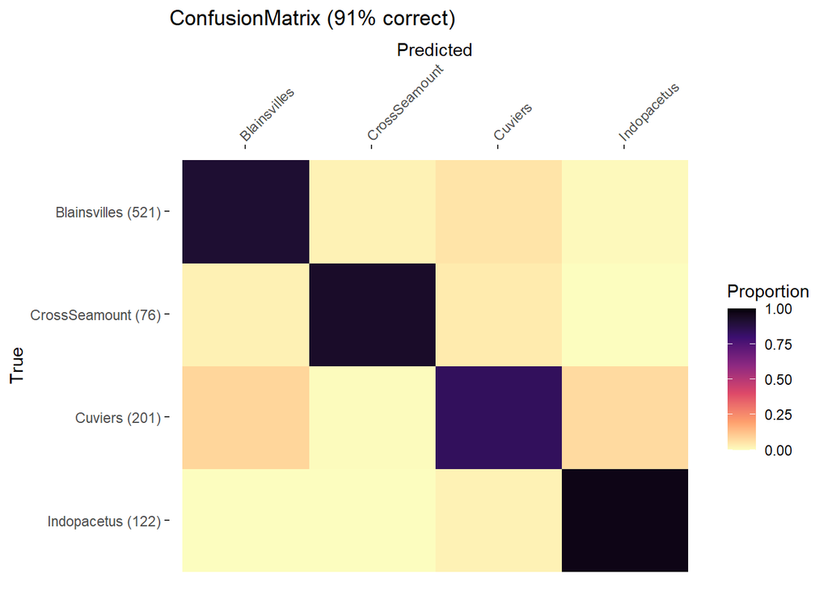

```r
plotConfMat(bntMdlRf, title="ConfusionMatrix", plot=TRUE)
```

Plot Error Trace for Banter Model

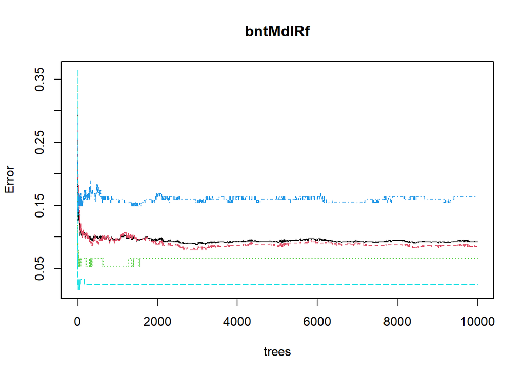

```r
plot(bntMdlRf)
```

PlotVotes

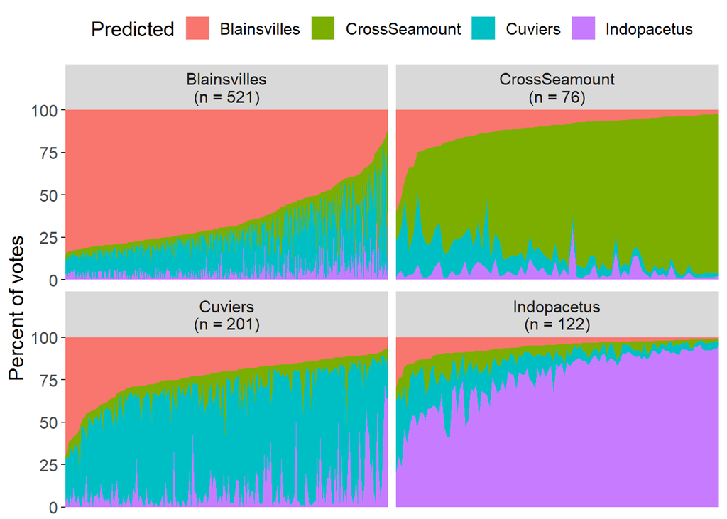

```r
plotVotes(bntMdlRf)
```

Importance Heatmap

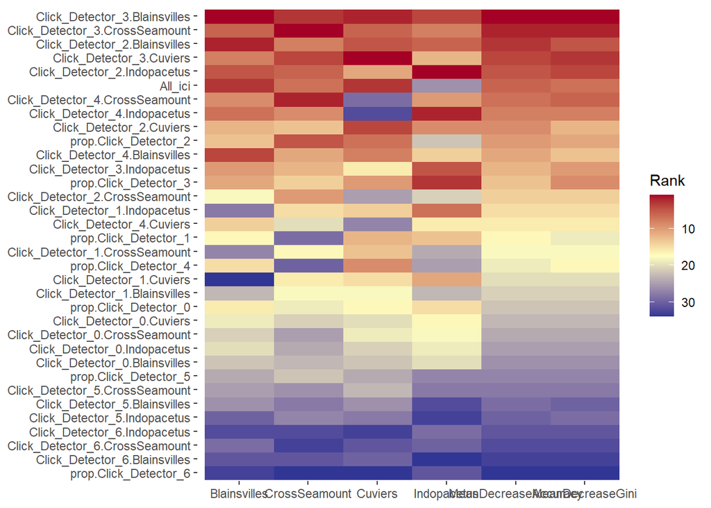

```r
plotImportance(bntMdlRf, plot.type="heatmap")
```

Proximity Plot

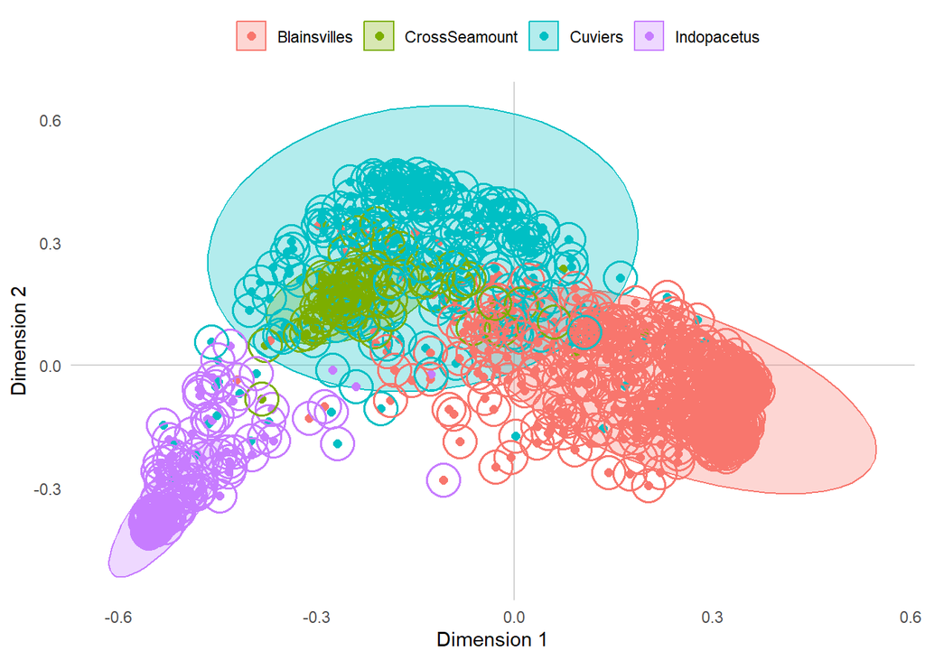

```r
plotProximity(bntMdlRf)
```

Plot Predicted Probabilities

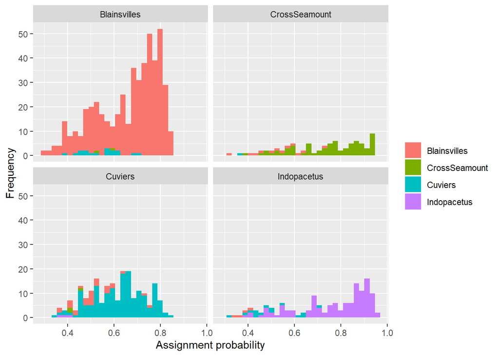

```r
plotPredictedProbs(bntMdlRf, bins=30, plot=TRUE)
```